# RA

Edison Alexis Toro Sanchez

27 de septiembre de 2018

# Encabezados Rmarckdown

Titulos tipo 1 (principal) se denotan con un #

Titulos tipo 2 (subtitulo) se denotan con dos ##

Titulos tipo 3 (Subtitulo del tipo 2) denotado con tres ###

(se debe de dar dos espacios para que el texto no quede pegado el uno del otro).

## Subtitulo

### Subtitulo del tipo 2

# Viñetas

- Viñeta 1
  - Subviñeta 1
    - Subviñeta 1.1
- Viñeta 2
  - Subviñeta 2
    - Subviñeta 2.1
- Viñeta 3
  - Subviñeta 3
    - Subviñeta 3.1

Tabular o indentar cada viñeta para no tener problemas en el documento

# Imagen

La imagen debe de estar en la carpeta de trabajo

[figure not shown]

# Imagen centrada

[figure not shown]

# Hipervinculo

Para el hipervinculo solo es necesario copiar y pegar la URL del mismo

https://www.elespectador.com/noticias/cultura/el-arte-de-ser-pessoa-articulo-747989

[El arte de ser Pessoa](https://www.elespectador.com/noticias/cultura/el-arte-de-ser-pessoa-articulo-747989)

# Hipervinculo 2

[Insomnio-Pessoa](https://lasotraspersonas.wordpress.com/2014/01/12/insomnio-de-fernando-pessoa/)

# Opciones de texto

*Esto es cursiva*

*Esto también es cursiva*

**Esto es negrilla**

**Esto es otra negrilla**

*Esto es negrilla y cursiva*

*Esto también es negrilla y cursiva*

(de nuevo dos espacios para separar el texto)

# Plot con R

CTRL+ALT+I para insertar un chunk de R

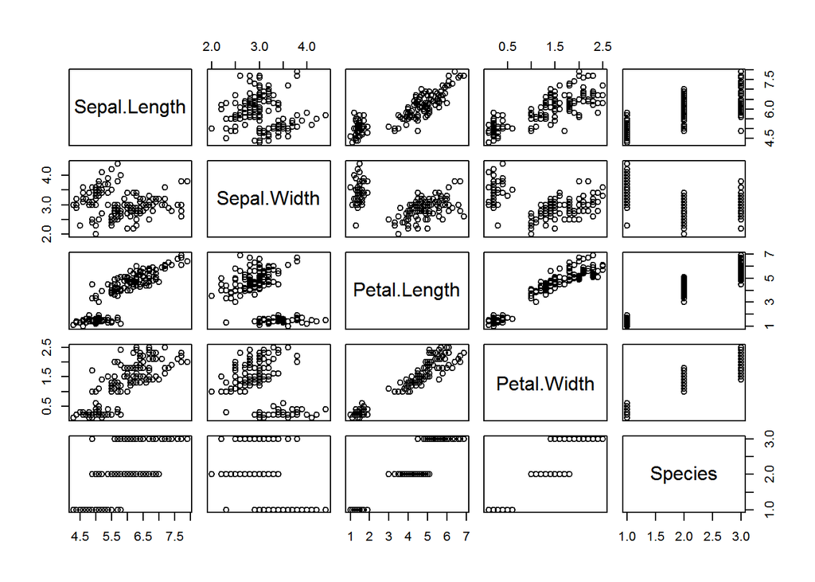

```r
plot(iris)
```

# Segundo Plot Con R

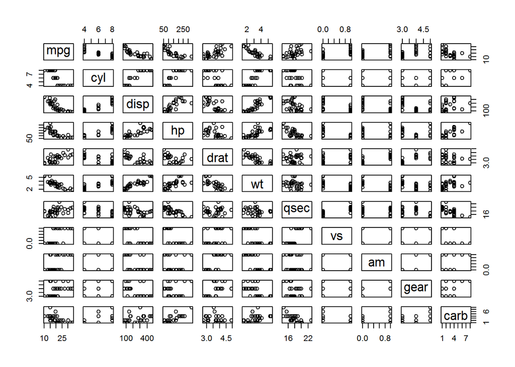

```r
plot(mtcars)
```

Para enviar a la nube en el recuadro de ambiente GIT>Commit(para registrar cambios comentarios)>Seleccionar la información a subir>push